# **Linde Chen**

## **Introduction**

In the internal dataset: NYTimes, we are given a list of newspaper headlines from 1996-2006. These headlines are categoried into topics from Topic Codes 1-31 and Topic Code 99. However, we are not given information about what these Topic Codes describe.

**Questions**

1. I will investigate the meaning of the Topic Codes through sentiment analysis. Specifically, I’m interested in the sentiments and words associated with the most positive and mmost negative topics. In this way, I hope to establish what categories these particular Topic Codes stand for.
2. Then, I will investigate the trend of these sentiments and words, as they are used in this news source, over the span of the NYTimes dataset.

From the graph that examines the distribution of mean sentiment scores with respect to each topic code, we discover that most topics contain predominantly negative sentiments. Next, we will examine the topics that 1) either have overwhelmingly negative sentiments, or have 2) predominantly positive sentiments.

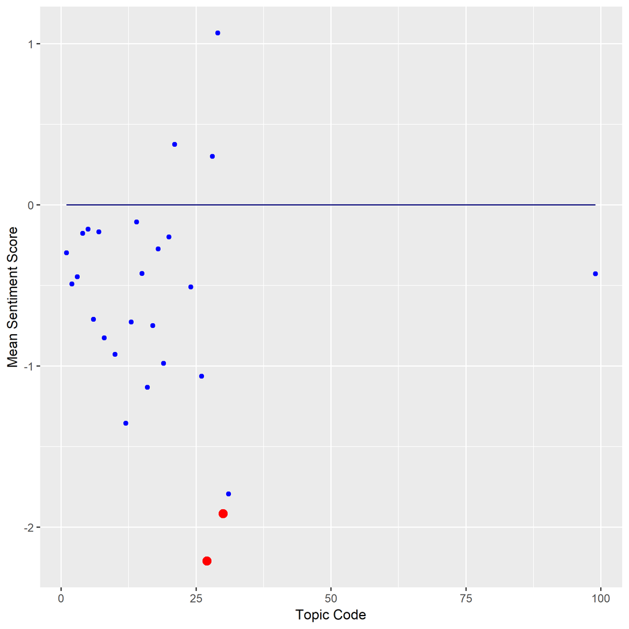

Topic codes 27 and 30, highlighted in red, appear to reflect the most negative sentiments, with mean sentiment scores of -2.210526 and -1.916667, respectively.

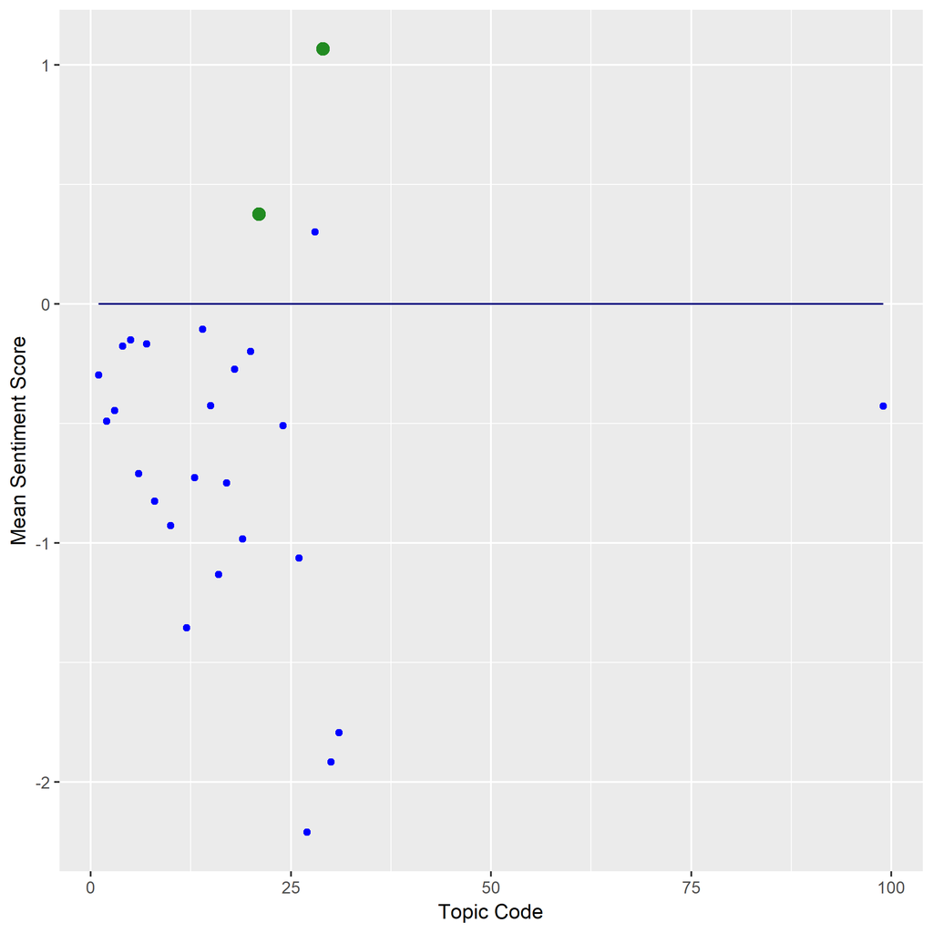